# Pandas

- Basic structures
- Indexing - loc, iloc
- Filtering
- Moving window / rolling technique
- Groupby, aggregation

```python
import os, glob
import pandas as pd
```

## Basic structures

### Index

Ndarray. Stores axis labels. Ordered, sliceable set.

### Series

Pandas series is Index + array of values. Similar to dict.

### Dataframe

Pandas DataFrame is a set of columns (Series) that share the same Index.

Pandas documentation: https://pandas.pydata.org/pandas-docs/stable/index.html

## Visualization imports

```python
%matplotlib inline
import matplotlib.pyplot as plt
```

**TIP: make the visualizations more beautiful :-)**

```python
%config InlineBackend.figure_format = 'retina'
plt.rcParams['figure.figsize'] = (24, 6) # redefine the default size of the plots
plt.rcParams['font.family'] = 'DejaVu Sans'
plt.style.use('ggplot')
```

## Load the data and have a first peek

Pandas are able to load from many possible sources. The loading functions are named `read_*` where * is usually the source type name.

```python
data_dir = 'data'
temperature = pd.read_csv(
    os.path.join(data_dir, '20191119_clementinum_temperature.csv'),
    names=['year', 'month', 'day', 'temperature_avg', 'temperature_max', 'temperature_min', 'rainfall', 'flag'],
    header=1
)
```

```python
temperature.head()
```

|  | year | month | day | temperature_avg | temperature_max | temperature_min | rainfall | flag |
| --- | --- | --- | --- | --- | --- | --- | --- | --- |
| 0 | 1775 | 1 | 2 | -2.2 | -1.4 | -5.8 | 0.3 | NaN |
| 1 | 1775 | 1 | 3 | -1.0 | 0.6 | -2.2 | 0.0 | NaN |
| 2 | 1775 | 1 | 4 | 0.1 | 2.5 | -3.6 | 1.2 | NaN |
| 3 | 1775 | 1 | 5 | 2.2 | 3.0 | 1.6 | 0.0 | NaN |
| 4 | 1775 | 1 | 6 | 3.2 | 4.0 | 1.6 | 0.3 | NaN |

## Merging, joining

Sometimes you need to combine different data frames.

https://pandas.pydata.org/pandas-docs/stable/merging.html

## Basic inspection methods

`head, tail, info, describe`

```python
temperature.info()
```

```
<class 'pandas.core.frame.DataFrame'>
RangeIndex: 89118 entries, 0 to 89117
Data columns (total 8 columns):
year               89118 non-null int64
month              89118 non-null int64
day                89118 non-null int64
temperature_avg    89118 non-null float64
temperature_max    89118 non-null float64
temperature_min    89118 non-null float64
rainfall           78758 non-null float64
flag               5740 non-null object
dtypes: float64(4), int64(3), object(1)
memory usage: 5.4+ MB
```

```python
temperature.describe()
```

|  | year | month | day | temperature_avg | temperature_max | temperature_min | rainfall |
| --- | --- | --- | --- | --- | --- | --- | --- |
| count | 89118.000000 | 89118.000000 | 89118.000000 | 89118.000000 | 89118.000000 | 89118.000000 | 78758.000000 |
| mean | 1896.502065 | 6.523093 | 15.729505 | 9.725833 | 13.220953 | 6.241437 | 1.291231 |
| std | 70.435799 | 3.448664 | 8.799927 | 8.337472 | 9.366338 | 7.565105 | 3.635070 |
| min | 1775.000000 | 1.000000 | 1.000000 | -24.800000 | -21.500000 | -27.600000 | 0.000000 |
| 25% | 1836.000000 | 4.000000 | 8.000000 | 3.300000 | 5.600000 | 1.000000 | 0.000000 |
| 50% | 1896.500000 | 7.000000 | 16.000000 | 9.900000 | 13.400000 | 6.400000 | 0.000000 |
| 75% | 1957.750000 | 10.000000 | 23.000000 | 16.700000 | 20.900000 | 12.500000 | 0.800000 |
| max | 2018.000000 | 12.000000 | 31.000000 | 31.900000 | 37.800000 | 24.000000 | 90.000000 |

```python
temperature['flag'].unique().tolist()
```

```
[nan, 'T']
```

## Cleaning up the data

Let's get rid of the `flag` column and create a DateTime as an index. Notice the method chaining.

**TIP: It is possible to chain also custom made function. Explore the pandas pipe method for more information.**

```python
temperature_cleaned = (
    temperature
    .drop('flag', axis='columns')
    .set_index(pd.to_datetime(temperature[['year', 'month', 'day']]))
)

temperature_cleaned.tail(2)
```

|  | year | month | day | temperature_avg | temperature_max | temperature_min | rainfall |
| --- | --- | --- | --- | --- | --- | --- | --- |
| 2018-12-30 | 2018 | 12 | 30 | 6.1 | 7.5 | 3.3 | 0.3 |
| 2018-12-31 | 2018 | 12 | 31 | 6.0 | 7.5 | 4.7 | 0.0 |

### How many years we have available?

Now, we will use our knowledge of the data to acquire some more basic informations by using the unique function.

```python
available_years = len(temperature['year'].unique())

f"Years with at least one entry: {available_years}, " \
f"Oldest entry: {temperature['year'].min()}, " \
f"Newest entry: {temperature['year'].max()}"
```

```
'Years with at least one entry: 244, Oldest entry: 1775, Newest entry: 2018'
```

## Indexing and Filtering

To select a subset of rows we will do the following:

- create a boolean series describing our selection criteria
- use the booolean series to select only the rows, where the series == True

```python
interesting_year = 2018
is_inspected_year = temperature_cleaned['year'] == interesting_year
is_inspected_year.head()
```

```
1775-01-02    False
1775-01-03    False
1775-01-04    False
1775-01-05    False
1775-01-06    False
Name: year, dtype: bool
```

```python
temperature_2018 = temperature_cleaned[is_inspected_year]
temperature_2018.head(2)
```

|  | year | month | day | temperature_avg | temperature_max | temperature_min | rainfall |
| --- | --- | --- | --- | --- | --- | --- | --- |
| 2018-01-01 | 2018 | 1 | 1 | 7.0 | 10.1 | 4.9 | 0.0 |
| 2018-01-02 | 2018 | 1 | 2 | 6.1 | 7.6 | 3.8 | 0.1 |

It is possible to limit rows and also columns by using the `loc[row_criteria, column_criteria]` function.

```python
rainfall_temperature_columns = ['temperature_avg', 'rainfall']
temperature_rainfall_2018 = temperature_cleaned.loc[is_inspected_year, rainfall_temperature_columns]
temperature_rainfall_2018.head(2)
```

|  | temperature_avg | rainfall |
| --- | --- | --- |
| 2018-01-01 | 7.0 | 0.0 |
| 2018-01-02 | 6.1 | 0.1 |

Notice the simplicity of plotting the pandas data.

**TIP: Also, notice the semicolon. It is suppressing any text output.**

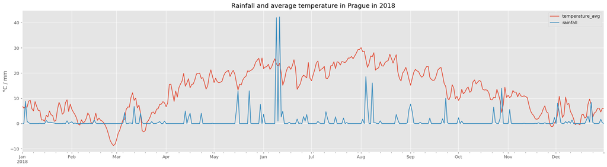

```python
temperature_rainfall_2018.plot(title='Rainfall and average temperature in Prague in 2018');
plt.ylabel("°C / mm");
```

The boolean series might be combined by using logic operators:

- & ... and
- | ... or
- ~ ... not

Let's practive this. We will visualize the snowy months for each year.

Snowy month := there is at least one day in the month where the temperature < 0 and rainfall > 0.

Moreover, we want to leverage the `alpha` (aka opacity) matplotlib parameter to distinguish between months with more and less snowy days. (The months with more snowy days are will be more dark.)

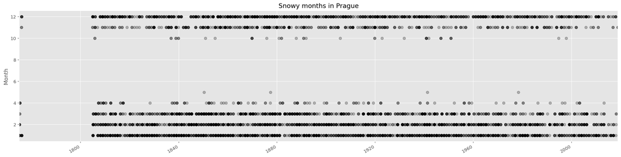

```python
rained = temperature_cleaned['rainfall'] > 0
above_zero = temperature_cleaned['temperature_min'] > 0

snow_days = temperature_cleaned.loc[rained & ~above_zero]

snow_days['month'].plot(title="Snowy months in Prague", marker='o', linestyle='None', alpha=0.25, color='black');
plt.ylabel("Month");
```

## Indexing - loc vs iloc

- loc: label-based selector
- iloc: position-based selector

```python
unsorted_letters = pd.DataFrame(data=['A', 'B', 'C', 'D', 'E'], index=[4, 5, 1, 2, 3], columns=['letters'])
unsorted_letters
```

|  | letters |
| --- | --- |
| 4 | A |
| 5 | B |
| 1 | C |
| 2 | D |
| 3 | E |

```python
unsorted_letters.loc[:2]
```

|  | letters |
| --- | --- |
| 4 | A |
| 5 | B |
| 1 | C |
| 2 | D |

```python
unsorted_letters.iloc[:2]
```

|  | letters |
| --- | --- |
| 4 | A |
| 5 | B |

```python
letter_index = unsorted_letters.reset_index().set_index('letters')
letter_index
```

| letters | index |
| --- | --- |
| A | 4 |
| B | 5 |
| C | 1 |
| D | 2 |
| E | 3 |

```python
letter_index.iloc[:2]
```

| letters | index |
| --- | --- |
| A | 4 |
| B | 5 |

Q: What will be the output of the following cell?

```python
letter_index.loc[:2]
```

[output not shown]

```python
letter_index.loc[:'B']
```

| letters | index |
| --- | --- |
| A | 4 |
| B | 5 |

**Note: Label-based slicing is inclusive.**

## Rolling operations

The rolling operation (moving window) requires a window of size N and a function f: [x1, ..., xN] -> y

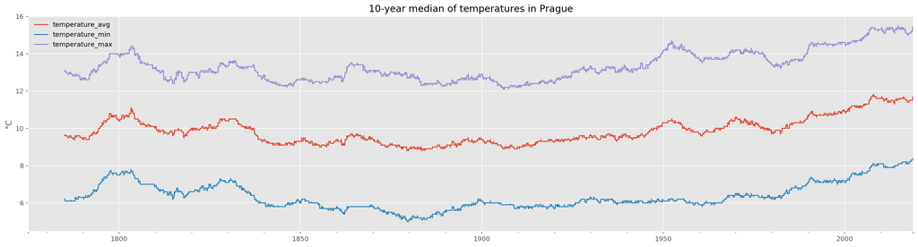

```python
temperature_cleaned[['temperature_avg', 'temperature_min', 'temperature_max']].rolling(window=10*365).median().plot(title="10-year median of temperatures in Prague");
plt.ylabel('°C');
```

## Aggregations - Difference between days and months

We want to explore the temperatures during different months and weekdays. First of all, we will select our columns of interest.

**TIP: Different ways how to define new column:**

```python
# providing a list of values
unsorted_letters["small_letters"] = ['a', 'b', 'c', 'd', 'e']
unsorted_letters
```

|  | letters | small_letters |
| --- | --- | --- |
| 4 | A | a |
| 5 | B | b |
| 1 | C | c |
| 2 | D | d |
| 3 | E | e |

```python
# vectorized calculation
unsorted_letters["both_letters"] = unsorted_letters['letters'] + unsorted_letters['small_letters']
unsorted_letters
```

|  | letters | small_letters | both_letters |
| --- | --- | --- | --- |
| 4 | A | a | Aa |
| 5 | B | b | Bb |
| 1 | C | c | Cc |
| 2 | D | d | Dd |
| 3 | E | e | Ee |

```python
# using assign method
unsorted_letters.assign(shifted=unsorted_letters['both_letters'].shift())
```

|  | letters | small_letters | both_letters | shifted |
| --- | --- | --- | --- | --- |
| 4 | A | a | Aa | NaN |
| 5 | B | b | Bb | Aa |
| 1 | C | c | Cc | Bb |
| 2 | D | d | Dd | Cc |
| 3 | E | e | Ee | Dd |

```python
temperature_columns = ['temperature_avg', 'temperature_min', 'temperature_max']

weekday_temperature = temperature_cleaned[temperature_columns].copy()
weekday_temperature['weekday'] = weekday_temperature.index.dayofweek

weekday_temperature.head()
```

|  | temperature_avg | temperature_min | temperature_max | weekday |
| --- | --- | --- | --- | --- |
| 1775-01-02 | -2.2 | -5.8 | -1.4 | 0 |
| 1775-01-03 | -1.0 | -2.2 | 0.6 | 1 |
| 1775-01-04 | 0.1 | -3.6 | 2.5 | 2 |
| 1775-01-05 | 2.2 | 1.6 | 3.0 | 3 |
| 1775-01-06 | 3.2 | 1.6 | 4.0 | 4 |

The next step is to group our data by the `weekday` column.

**TIP: It is also possible to group by the index values, just use `grouby(level=0)`**

```python
weekday_temperature_grouped = weekday_temperature.groupby('weekday')
weekday_temperature_grouped
```

```
<pandas.core.groupby.generic.DataFrameGroupBy object at 0x0000013FD9E43828>
```

Different aggregation function might be called on the groupby object.

The weekday contains number 0-6 (0 ... Monday, 6 ... Sunday). If we use a mean aggregation, we can see the weekends are slightly colder than the work/school days. What a pitty!

```python
median_weekday_temperatures = weekday_temperature_grouped.mean()
median_weekday_temperatures
```

| weekday | temperature_avg | temperature_min | temperature_max |
| --- | --- | --- | --- |
| 0 | 9.764067 | 6.265481 | 13.260226 |
| 1 | 9.720807 | 6.253986 | 13.228097 |
| 2 | 9.733650 | 6.214076 | 13.236321 |
| 3 | 9.747035 | 6.262689 | 13.232637 |
| 4 | 9.735614 | 6.258864 | 13.216024 |
| 5 | 9.685335 | 6.230885 | 13.171141 |
| 6 | 9.694321 | 6.204077 | 13.202223 |

**TIP: There is a way to access the actual grouped data.**

```python
weekday_temperature_grouped.get_group(0).head()  # Monday data
```

|  | temperature_avg | temperature_min | temperature_max | weekday |
| --- | --- | --- | --- | --- |
| 1775-01-02 | -2.2 | -5.8 | -1.4 | 0 |
| 1775-01-09 | 4.0 | 2.7 | 6.3 | 0 |
| 1775-01-16 | 0.1 | -0.9 | 2.0 | 0 |
| 1775-01-23 | -5.0 | -7.0 | -2.3 | 0 |
| 1775-01-30 | 8.5 | 5.7 | 10.5 | 0 |

**TIP: It is possible to define a very specific combination of aggregation functions for each column.**

```python
import numpy as np

multiple_aggregation = weekday_temperature_grouped.agg({
    "temperature_avg": [np.mean],
    "temperature_min": [np.mean, np.min],
    "temperature_max": [np.mean, np.max]
})
multiple_aggregation
```

| weekday | temperature_avg mean | temperature_min mean | temperature_min amin | temperature_max mean | temperature_max amax |
| --- | --- | --- | --- | --- | --- |
| 0 | 9.764067 | 6.265481 | -27.2 | 13.260226 | 37.3 |
| 1 | 9.720807 | 6.253986 | -27.6 | 13.228097 | 36.1 |
| 2 | 9.733650 | 6.214076 | -26.5 | 13.236321 | 37.8 |
| 3 | 9.747035 | 6.262689 | -25.4 | 13.232637 | 37.2 |
| 4 | 9.735614 | 6.258864 | -27.0 | 13.216024 | 36.4 |
| 5 | 9.685335 | 6.230885 | -25.8 | 13.171141 | 36.8 |
| 6 | 9.694321 | 6.204077 | -27.5 | 13.202223 | 37.6 |

Example of accessing the multi-dimensional columns.

```python
multiple_aggregation['temperature_min']['amin']
```

```
weekday
0   -27.2
1   -27.6
2   -26.5
3   -25.4
4   -27.0
5   -25.8
6   -27.5
Name: amin, dtype: float64
```

## Outlier detection

Q: What visualization will help me to spot outliers?

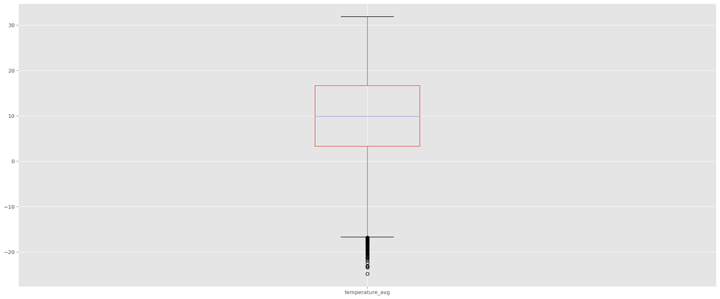

```python
temperature_cleaned['temperature_avg'].plot.box(
    figsize=(24,10),
    showfliers=True
);
```

### IQR outlier detection

- `IQR = quartile3 - quartile1`
- `outlier := (x > quartile3 + 1.5 * IQR) or (x < quartile1 - 1.5 * IQR)`

```python
def is_iqr_outlier(x, quartile1, quartile3):
    iqr = quartile3 - quartile1
    return (x > quartile3 + 1.5 * iqr) or (x < quartile1 - 1.5 * iqr)

quartile1 = temperature_cleaned.temperature_avg.quantile(0.25)
quartile3 = temperature_cleaned.temperature_avg.quantile(0.75)

is_temperature_outlier = temperature_cleaned.temperature_avg.apply(
    lambda temperature_avg: is_iqr_outlier(x=temperature_avg, quartile1=quartile1, quartile3=quartile3)
)

is_temperature_outlier.head()
```

```
1775-01-02    False
1775-01-03    False
1775-01-04    False
1775-01-05    False
1775-01-06    False
Name: temperature_avg, dtype: bool
```

```python
temperature_cleaned[is_temperature_outlier]
```

|  | year | month | day | temperature_avg | temperature_max | temperature_min | rainfall |
| --- | --- | --- | --- | --- | --- | --- | --- |
| 1776-01-20 | 1776 | 1 | 20 | -18.5 | -15.7 | -19.6 | NaN |
| 1776-01-28 | 1776 | 1 | 28 | -17.4 | -14.4 | -22.7 | NaN |
| 1776-01-29 | 1776 | 1 | 29 | -18.0 | -14.1 | -22.0 | NaN |
| 1776-01-30 | 1776 | 1 | 30 | -17.3 | -14.3 | -19.2 | NaN |
| 1776-02-01 | 1776 | 2 | 1 | -18.0 | -14.4 | -21.5 | NaN |
| ... | ... | ... | ... | ... | ... | ... | ... |
| 1956-02-10 | 1956 | 2 | 10 | -19.2 | -16.8 | -24.3 | 0.0 |
| 1969-12-22 | 1969 | 12 | 22 | -17.0 | -15.5 | -20.0 | 0.0 |
| 1985-01-07 | 1985 | 1 | 7 | -16.8 | -10.8 | -19.2 | 0.0 |
| 1985-01-08 | 1985 | 1 | 8 | -18.0 | -14.3 | -20.2 | 0.0 |
| 1985-01-09 | 1985 | 1 | 9 | -17.2 | -13.0 | -20.2 | 0.0 |

104 rows × 7 columns

Q: Could we avoid using the apply function in this case and be a little bit more elegant?

```python
iqr_distance = 1.5 * (quartile3 - quartile1)
upper_bound = quartile3 + iqr_distance
lower_bound = quartile1 - iqr_distance

is_temperature_outlier_condition = (
    (temperature_cleaned.temperature_avg > upper_bound) |
    (temperature_cleaned.temperature_avg < lower_bound)
)

temperature_cleaned[is_temperature_outlier_condition]
```

|  | year | month | day | temperature_avg | temperature_max | temperature_min | rainfall |
| --- | --- | --- | --- | --- | --- | --- | --- |
| 1776-01-20 | 1776 | 1 | 20 | -18.5 | -15.7 | -19.6 | NaN |
| 1776-01-28 | 1776 | 1 | 28 | -17.4 | -14.4 | -22.7 | NaN |
| 1776-01-29 | 1776 | 1 | 29 | -18.0 | -14.1 | -22.0 | NaN |
| 1776-01-30 | 1776 | 1 | 30 | -17.3 | -14.3 | -19.2 | NaN |
| 1776-02-01 | 1776 | 2 | 1 | -18.0 | -14.4 | -21.5 | NaN |
| ... | ... | ... | ... | ... | ... | ... | ... |
| 1956-02-10 | 1956 | 2 | 10 | -19.2 | -16.8 | -24.3 | 0.0 |
| 1969-12-22 | 1969 | 12 | 22 | -17.0 | -15.5 | -20.0 | 0.0 |
| 1985-01-07 | 1985 | 1 | 7 | -16.8 | -10.8 | -19.2 | 0.0 |
| 1985-01-08 | 1985 | 1 | 8 | -18.0 | -14.3 | -20.2 | 0.0 |
| 1985-01-09 | 1985 | 1 | 9 | -17.2 | -13.0 | -20.2 | 0.0 |

104 rows × 7 columns

## Split - apply - combine

Motivation: I want to compare distribution of temperatures between different months

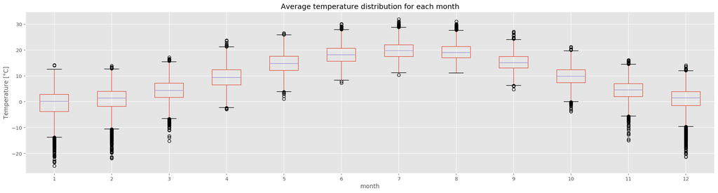

```python
temperature_cleaned.boxplot(by='month', column='temperature_avg');
plt.title('Average temperature distribution for each month');
plt.suptitle('');
plt.ylabel('Temperature [°C]');
```

But how to compare the distributions? I want normalize temperatures into <0, 1> interval for each month.

### Min-max scaling

- `x' = (x - min) / (max - min)`

### Split - apply - combine usage

1. **Split** data set on months.
2. **Apply** min-max scaling for each group separately.
3. **Combine** the groups back together.

```python
def min_max_scale(x: pd.Series) -> pd.Series:
    minimum = x.min()
    maximum = x.max()

    return (x - minimum) / (maximum - minimum)

month_temperatures = temperature_cleaned.copy()

month_temperatures['temperature_avg_scaled'] = temperature_cleaned.groupby('month').apply(min_max_scale)['temperature_avg']

month_temperatures.head()
```

|  | year | month | day | temperature_avg | temperature_max | temperature_min | rainfall | temperature_avg_scaled |
| --- | --- | --- | --- | --- | --- | --- | --- | --- |
| 1775-01-02 | 1775 | 1 | 2 | -2.2 | -1.4 | -5.8 | 0.3 | 0.579487 |
| 1775-01-03 | 1775 | 1 | 3 | -1.0 | 0.6 | -2.2 | 0.0 | 0.610256 |
| 1775-01-04 | 1775 | 1 | 4 | 0.1 | 2.5 | -3.6 | 1.2 | 0.638462 |
| 1775-01-05 | 1775 | 1 | 5 | 2.2 | 3.0 | 1.6 | 0.0 | 0.692308 |
| 1775-01-06 | 1775 | 1 | 6 | 3.2 | 4.0 | 1.6 | 0.3 | 0.717949 |

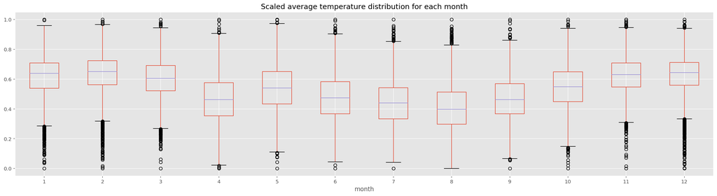

```python
month_temperatures.boxplot(by='month', column='temperature_avg_scaled');
plt.title('Scaled average temperature distribution for each month');
plt.suptitle('');
```

## Pivoting (stack, unstack, pivot)

```python
rainfall_per_day = temperature_cleaned.groupby(['month', 'day']).mean()
rainfall_per_day
```

| month | day | year | temperature_avg | temperature_max | temperature_min | rainfall |
| --- | --- | --- | --- | --- | --- | --- |
| 1 | 1 | 1897.0 | -0.805761 | 1.346502 | -2.997531 | 0.997196 |
|  | 2 | 1896.5 | -0.599590 | 1.322131 | -2.922951 | 0.666512 |
|  | 3 | 1896.5 | -0.514754 | 1.478689 | -2.763525 | 0.621860 |
|  | 4 | 1896.5 | -0.754508 | 1.378689 | -2.842623 | 0.832093 |
|  | 5 | 1896.5 | -0.930738 | 1.047541 | -3.192213 | 0.819535 |
| ... | ... | ... | ... | ... | ... | ... |
| 12 | 27 | 1896.5 | -0.219672 | 1.709836 | -2.268033 | 0.713426 |
|  | 28 | 1896.5 | 0.031967 | 2.015984 | -2.288934 | 0.974074 |
|  | 29 | 1896.5 | -0.221311 | 1.881148 | -2.365574 | 0.992130 |
|  | 30 | 1896.5 | -0.288115 | 1.887295 | -2.615164 | 1.011574 |
|  | 31 | 1896.5 | -0.459426 | 1.616393 | -2.760656 | 0.718981 |

366 rows × 5 columns

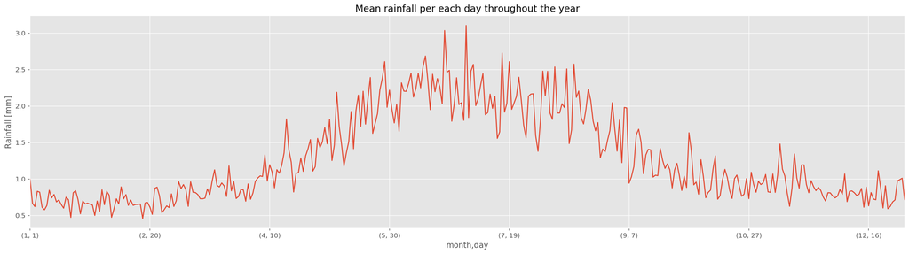

```python
rainfall_per_day['rainfall'].plot(title='Mean rainfall per each day throughout the year');
plt.ylabel('Rainfall [mm]');
```

```python
rainfall_per_day_stacked = rainfall_per_day.stack()
rainfall_per_day_stacked
```

```
month  day
1      1    year               1897.000000
            temperature_avg      -0.805761
            temperature_max       1.346502
            temperature_min      -2.997531
            rainfall              0.997196
                                  ...
12     31   year               1896.500000
            temperature_avg      -0.459426
            temperature_max       1.616393
            temperature_min      -2.760656
            rainfall              0.718981
Length: 1830, dtype: float64
```

```python
rainfall_per_day[['rainfall']].unstack()
```

| day month | rainfall 1 | rainfall 2 | rainfall 3 | rainfall 4 | rainfall 5 | rainfall 6 | rainfall 7 | rainfall 8 | rainfall 9 | rainfall 10 | rainfall ... | rainfall 22 | rainfall 23 | rainfall 24 | rainfall 25 | rainfall 26 | rainfall 27 | rainfall 28 | rainfall 29 | rainfall 30 | rainfall 31 |
| --- | --- | --- | --- | --- | --- | --- | --- | --- | --- | --- | --- | --- | --- | --- | --- | --- | --- | --- | --- | --- | --- |
| 1 | 0.997196 | 0.666512 | 0.621860 | 0.832093 | 0.819535 | 0.613023 | 0.578605 | 0.637674 | 0.846512 | 0.740930 | ... | 0.523364 | 0.699533 | 0.657944 | 0.669159 | 0.655607 | 0.643925 | 0.500935 | 0.698598 | 0.555607 | 0.852336 |
| 2 | 0.647442 | 0.831628 | 0.777209 | 0.474419 | 0.589767 | 0.729302 | 0.658605 | 0.892558 | 0.727907 | 0.786512 | ... | 0.872558 | 0.888372 | 0.769767 | 0.538140 | 0.581860 | 0.632093 | 0.609302 | 0.796154 | NaN | NaN |
| 3 | 0.623721 | 0.702791 | 0.965116 | 0.869302 | 0.923721 | 0.855349 | 0.625581 | 0.961395 | 0.818140 | 0.814419 | ... | 0.906047 | 0.760930 | 1.179535 | 0.838140 | 0.964651 | 0.732558 | 0.760930 | 0.857209 | 0.850698 | 0.695814 |
| 4 | 0.933488 | 0.721860 | 0.806977 | 0.966512 | 1.013488 | 1.042791 | 1.034884 | 1.329302 | 0.971628 | 1.195814 | ... | 1.087907 | 1.288372 | 1.104186 | 1.317674 | 1.414419 | 1.541395 | 1.107907 | 1.168372 | 1.557674 | NaN |
| 5 | 1.430556 | 1.508796 | 1.705556 | 1.481944 | 1.818981 | 1.253241 | 1.466667 | 2.189815 | 1.723611 | 1.475463 | ... | 2.392130 | 1.625463 | 1.758796 | 1.895833 | 2.224074 | 2.377778 | 2.610648 | 1.983333 | 2.218981 | 1.960648 |
| 6 | 1.768981 | 2.028241 | 1.654630 | 2.318981 | 2.205093 | 2.202315 | 2.311111 | 2.451389 | 2.123611 | 2.238889 | ... | 3.036111 | 2.463889 | 2.489815 | 1.792130 | 2.025000 | 2.389352 | 2.021296 | 2.046296 | 1.804167 | NaN |
| 7 | 3.106481 | 1.842593 | 2.479630 | 2.571759 | 2.006019 | 2.100926 | 2.281481 | 2.443519 | 1.881944 | 1.910648 | ... | 2.132870 | 2.395833 | 2.084259 | 1.739815 | 1.565278 | 2.134722 | 2.164815 | 2.169444 | 1.599074 | 1.380093 |
| 8 | 1.796296 | 2.479630 | 2.141667 | 2.477315 | 1.906019 | 1.817593 | 2.537037 | 1.906019 | 1.904630 | 2.032870 | ... | 2.079630 | 1.794907 | 1.661574 | 1.774074 | 1.292130 | 1.411111 | 1.370370 | 1.528704 | 1.663889 | 2.047222 |
| 9 | 1.696296 | 1.381944 | 1.808333 | 1.223611 | 1.981019 | 1.975000 | 0.943056 | 1.031481 | 1.168981 | 1.605093 | ... | 1.145370 | 1.207870 | 1.126852 | 0.877778 | 1.124537 | 1.215278 | 1.046759 | 0.842593 | 1.038426 | NaN |
| 10 | 0.883796 | 1.634722 | 1.383333 | 0.919907 | 0.958333 | 0.791667 | 1.265278 | 1.037500 | 0.743056 | 0.815278 | ... | 1.054167 | 0.901389 | 0.763426 | 0.792130 | 1.005556 | 0.730556 | 1.093519 | 0.926389 | 0.818519 | 0.968056 |
| 11 | 0.924074 | 0.950000 | 1.062963 | 0.824537 | 0.817593 | 1.069444 | 0.816204 | 1.053241 | 1.480093 | 1.137037 | ... | 0.976852 | 0.897222 | 0.840278 | 0.887037 | 0.843981 | 0.755556 | 0.698148 | 0.812500 | 0.810185 | NaN |
| 12 | 0.767593 | 0.741667 | 0.765278 | 0.856019 | 0.790278 | 1.069907 | 0.689815 | 0.830556 | 0.837037 | 0.812500 | ... | 0.603241 | 0.907870 | 0.593056 | 0.623148 | 0.685648 | 0.713426 | 0.974074 | 0.992130 | 1.011574 | 0.718981 |

12 rows × 31 columns

```python
temperature_heatmap = temperature_cleaned.pivot_table(values='temperature_avg', index='day', columns='month', aggfunc=np.mean)
temperature_heatmap
```

| month day | 1 | 2 | 3 | 4 | 5 | 6 | 7 | 8 | 9 | 10 | 11 | 12 |
| --- | --- | --- | --- | --- | --- | --- | --- | --- | --- | --- | --- | --- |
| 1 | -0.805761 | -0.064754 | 2.246311 | 7.203689 | 12.406967 | 16.937295 | 19.020902 | 20.388934 | 17.222131 | 12.951639 | 6.960246 | 2.334836 |
| 2 | -0.599590 | 0.172541 | 2.347541 | 7.512295 | 12.700820 | 17.350000 | 19.048361 | 20.379098 | 17.214754 | 12.800000 | 6.704098 | 2.228279 |
| 3 | -0.514754 | 0.362705 | 2.506148 | 7.702049 | 12.701639 | 17.575820 | 19.354918 | 20.297541 | 17.316803 | 12.558607 | 6.640984 | 2.018033 |
| 4 | -0.754508 | 0.356967 | 2.617623 | 7.793033 | 12.957377 | 17.712295 | 19.577459 | 20.107377 | 17.087295 | 12.257787 | 6.583197 | 2.131967 |
| 5 | -0.930738 | 0.362705 | 2.688934 | 7.747131 | 13.020492 | 17.730328 | 19.468852 | 20.059016 | 16.818033 | 12.059016 | 6.315164 | 2.254508 |
| 6 | -0.876230 | 0.340574 | 2.909836 | 7.870082 | 13.394672 | 17.715164 | 19.454918 | 20.143033 | 16.852869 | 12.031967 | 6.033197 | 2.207787 |
| 7 | -0.992213 | 0.258607 | 3.079918 | 8.199590 | 13.705328 | 17.880738 | 19.536475 | 19.927459 | 16.801230 | 11.875820 | 5.952869 | 1.958607 |
| 8 | -1.021311 | 0.392213 | 3.221721 | 8.150410 | 13.913115 | 17.926230 | 19.650820 | 19.997951 | 16.642213 | 11.678279 | 5.909426 | 1.729508 |
| 9 | -1.178689 | 0.369262 | 3.384016 | 8.293033 | 14.000410 | 18.079098 | 19.597541 | 19.738525 | 16.384836 | 11.395492 | 5.590984 | 1.463934 |
| 10 | -1.104098 | 0.181967 | 3.368443 | 8.285656 | 14.030738 | 18.084836 | 19.642623 | 19.693852 | 16.339754 | 10.974180 | 5.093852 | 1.325000 |
| 11 | -1.088115 | 0.370902 | 3.325820 | 8.603279 | 14.100410 | 17.987705 | 19.640984 | 19.715984 | 16.115984 | 10.737295 | 4.960656 | 1.499590 |
| 12 | -1.156967 | 0.333197 | 3.331967 | 8.708607 | 14.385656 | 17.740164 | 19.718443 | 19.518033 | 15.782787 | 10.460656 | 4.720082 | 1.367623 |
| 13 | -1.212295 | 0.034836 | 3.360656 | 8.872541 | 14.393443 | 17.950410 | 19.751639 | 19.558607 | 15.529098 | 10.289344 | 4.617213 | 1.215574 |
| 14 | -1.193443 | 0.136885 | 3.523361 | 9.195082 | 14.416803 | 17.837705 | 20.012295 | 19.588115 | 15.387705 | 10.090164 | 4.312295 | 0.934836 |
| 15 | -1.189754 | 0.426230 | 3.861475 | 9.481557 | 14.557377 | 17.764754 | 20.071311 | 19.689344 | 15.272131 | 10.010246 | 4.243033 | 0.863934 |
| 16 | -0.994262 | 0.637295 | 4.182787 | 9.608607 | 14.867213 | 17.633607 | 20.008607 | 19.388934 | 15.011475 | 9.634836 | 4.231557 | 0.941803 |
| 17 | -0.724590 | 0.646721 | 4.511066 | 9.505328 | 14.953689 | 17.858607 | 19.927049 | 19.107377 | 15.200820 | 9.609016 | 4.026230 | 0.671721 |
| 18 | -0.702869 | 0.727459 | 4.745902 | 9.656557 | 15.243443 | 18.030738 | 20.062295 | 19.076230 | 15.093033 | 9.390574 | 3.899180 | 0.515574 |
| 19 | -0.509016 | 0.688525 | 4.597541 | 9.936885 | 15.185656 | 18.123361 | 20.011066 | 19.157787 | 14.730738 | 9.089754 | 3.701639 | 0.503689 |
| 20 | -0.540574 | 0.883197 | 4.546721 | 10.143033 | 15.251639 | 18.397951 | 20.052049 | 19.055328 | 14.359426 | 8.951230 | 3.453689 | 0.326230 |
| 21 | -0.783197 | 0.942623 | 4.880738 | 10.409016 | 15.543033 | 18.326230 | 20.029098 | 18.998770 | 14.111066 | 8.627049 | 3.234016 | 0.184836 |
| 22 | -1.074590 | 1.236066 | 4.864754 | 10.540984 | 15.442213 | 18.476230 | 20.069672 | 18.805328 | 13.990164 | 8.305738 | 3.146311 | 0.247541 |
| 23 | -0.895902 | 1.404508 | 5.030328 | 10.782377 | 15.686475 | 18.501639 | 20.135246 | 18.535656 | 13.820492 | 8.353689 | 3.341393 | 0.379098 |
| 24 | -0.556967 | 1.702459 | 5.480328 | 11.091393 | 16.028689 | 18.431557 | 20.019262 | 18.304098 | 13.740164 | 8.404918 | 3.083607 | 0.249180 |
| 25 | -0.284016 | 1.946311 | 5.718852 | 11.134836 | 16.104098 | 18.341803 | 19.922541 | 18.244672 | 13.751639 | 8.161475 | 2.855328 | 0.204098 |
| 26 | -0.563525 | 2.200820 | 5.799180 | 11.174590 | 16.069672 | 18.647951 | 20.282377 | 18.267623 | 13.515574 | 7.891803 | 2.686475 | -0.026639 |
| 27 | -0.500820 | 2.013934 | 6.044672 | 11.297541 | 16.312705 | 18.802049 | 20.304098 | 18.222131 | 13.474590 | 7.677459 | 2.805328 | -0.219672 |
| 28 | -0.283197 | 2.149180 | 6.273770 | 11.619672 | 16.376230 | 18.776639 | 20.150410 | 18.025820 | 13.479508 | 7.591803 | 2.889754 | 0.031967 |
| 29 | -0.072541 | 2.311864 | 6.517623 | 11.922951 | 16.745902 | 19.068033 | 20.170492 | 18.014344 | 13.245082 | 7.337295 | 2.835656 | -0.221311 |
| 30 | -0.126639 | NaN | 6.840164 | 12.112705 | 16.762295 | 19.226639 | 20.164754 | 17.737295 | 13.150410 | 7.084426 | 2.663934 | -0.288115 |
| 31 | -0.143443 | NaN | 7.008197 | NaN | 16.761885 | NaN | 20.387295 | 17.647951 | NaN | 7.107377 | NaN | -0.459426 |

```python
temperature_heatmap.style.background_gradient(cmap='BuPu', axis='columns')
```

| month day | 1 | 2 | 3 | 4 | 5 | 6 | 7 | 8 | 9 | 10 | 11 | 12 |
| --- | --- | --- | --- | --- | --- | --- | --- | --- | --- | --- | --- | --- |
| 1 | -0.805761 | -0.0647541 | 2.24631 | 7.20369 | 12.407 | 16.9373 | 19.0209 | 20.3889 | 17.2221 | 12.9516 | 6.96025 | 2.33484 |
| 2 | -0.59959 | 0.172541 | 2.34754 | 7.5123 | 12.7008 | 17.35 | 19.0484 | 20.3791 | 17.2148 | 12.8 | 6.7041 | 2.22828 |
| 3 | -0.514754 | 0.362705 | 2.50615 | 7.70205 | 12.7016 | 17.5758 | 19.3549 | 20.2975 | 17.3168 | 12.5586 | 6.64098 | 2.01803 |
| 4 | -0.754508 | 0.356967 | 2.61762 | 7.79303 | 12.9574 | 17.7123 | 19.5775 | 20.1074 | 17.0873 | 12.2578 | 6.5832 | 2.13197 |
| 5 | -0.930738 | 0.362705 | 2.68893 | 7.74713 | 13.0205 | 17.7303 | 19.4689 | 20.059 | 16.818 | 12.059 | 6.31516 | 2.25451 |
| 6 | -0.87623 | 0.340574 | 2.90984 | 7.87008 | 13.3947 | 17.7152 | 19.4549 | 20.143 | 16.8529 | 12.032 | 6.0332 | 2.20779 |
| 7 | -0.992213 | 0.258607 | 3.07992 | 8.19959 | 13.7053 | 17.8807 | 19.5365 | 19.9275 | 16.8012 | 11.8758 | 5.95287 | 1.95861 |
| 8 | -1.02131 | 0.392213 | 3.22172 | 8.15041 | 13.9131 | 17.9262 | 19.6508 | 19.998 | 16.6422 | 11.6783 | 5.90943 | 1.72951 |
| 9 | -1.17869 | 0.369262 | 3.38402 | 8.29303 | 14.0004 | 18.0791 | 19.5975 | 19.7385 | 16.3848 | 11.3955 | 5.59098 | 1.46393 |
| 10 | -1.1041 | 0.181967 | 3.36844 | 8.28566 | 14.0307 | 18.0848 | 19.6426 | 19.6939 | 16.3398 | 10.9742 | 5.09385 | 1.325 |
| 11 | -1.08811 | 0.370902 | 3.32582 | 8.60328 | 14.1004 | 17.9877 | 19.641 | 19.716 | 16.116 | 10.7373 | 4.96066 | 1.49959 |
| 12 | -1.15697 | 0.333197 | 3.33197 | 8.70861 | 14.3857 | 17.7402 | 19.7184 | 19.518 | 15.7828 | 10.4607 | 4.72008 | 1.36762 |
| 13 | -1.2123 | 0.0348361 | 3.36066 | 8.87254 | 14.3934 | 17.9504 | 19.7516 | 19.5586 | 15.5291 | 10.2893 | 4.61721 | 1.21557 |
| 14 | -1.19344 | 0.136885 | 3.52336 | 9.19508 | 14.4168 | 17.8377 | 20.0123 | 19.5881 | 15.3877 | 10.0902 | 4.3123 | 0.934836 |
| 15 | -1.18975 | 0.42623 | 3.86148 | 9.48156 | 14.5574 | 17.7648 | 20.0713 | 19.6893 | 15.2721 | 10.0102 | 4.24303 | 0.863934 |
| 16 | -0.994262 | 0.637295 | 4.18279 | 9.60861 | 14.8672 | 17.6336 | 20.0086 | 19.3889 | 15.0115 | 9.63484 | 4.23156 | 0.941803 |
| 17 | -0.72459 | 0.646721 | 4.51107 | 9.50533 | 14.9537 | 17.8586 | 19.927 | 19.1074 | 15.2008 | 9.60902 | 4.02623 | 0.671721 |
| 18 | -0.702869 | 0.727459 | 4.7459 | 9.65656 | 15.2434 | 18.0307 | 20.0623 | 19.0762 | 15.093 | 9.39057 | 3.89918 | 0.515574 |
| 19 | -0.509016 | 0.688525 | 4.59754 | 9.93689 | 15.1857 | 18.1234 | 20.0111 | 19.1578 | 14.7307 | 9.08975 | 3.70164 | 0.503689 |
| 20 | -0.540574 | 0.883197 | 4.54672 | 10.143 | 15.2516 | 18.398 | 20.052 | 19.0553 | 14.3594 | 8.95123 | 3.45369 | 0.32623 |
| 21 | -0.783197 | 0.942623 | 4.88074 | 10.409 | 15.543 | 18.3262 | 20.0291 | 18.9988 | 14.1111 | 8.62705 | 3.23402 | 0.184836 |
| 22 | -1.07459 | 1.23607 | 4.86475 | 10.541 | 15.4422 | 18.4762 | 20.0697 | 18.8053 | 13.9902 | 8.30574 | 3.14631 | 0.247541 |
| 23 | -0.895902 | 1.40451 | 5.03033 | 10.7824 | 15.6865 | 18.5016 | 20.1352 | 18.5357 | 13.8205 | 8.35369 | 3.34139 | 0.379098 |
| 24 | -0.556967 | 1.70246 | 5.48033 | 11.0914 | 16.0287 | 18.4316 | 20.0193 | 18.3041 | 13.7402 | 8.40492 | 3.08361 | 0.24918 |
| 25 | -0.284016 | 1.94631 | 5.71885 | 11.1348 | 16.1041 | 18.3418 | 19.9225 | 18.2447 | 13.7516 | 8.16148 | 2.85533 | 0.204098 |
| 26 | -0.563525 | 2.20082 | 5.79918 | 11.1746 | 16.0697 | 18.648 | 20.2824 | 18.2676 | 13.5156 | 7.8918 | 2.68648 | -0.0266393 |
| 27 | -0.50082 | 2.01393 | 6.04467 | 11.2975 | 16.3127 | 18.802 | 20.3041 | 18.2221 | 13.4746 | 7.67746 | 2.80533 | -0.219672 |
| 28 | -0.283197 | 2.14918 | 6.27377 | 11.6197 | 16.3762 | 18.7766 | 20.1504 | 18.0258 | 13.4795 | 7.5918 | 2.88975 | 0.0319672 |
| 29 | -0.072541 | 2.31186 | 6.51762 | 11.923 | 16.7459 | 19.068 | 20.1705 | 18.0143 | 13.2451 | 7.3373 | 2.83566 | -0.221311 |
| 30 | -0.126639 | nan | 6.84016 | 12.1127 | 16.7623 | 19.2266 | 20.1648 | 17.7373 | 13.1504 | 7.08443 | 2.66393 | -0.288115 |
| 31 | -0.143443 | nan | 7.0082 | nan | 16.7619 | nan | 20.3873 | 17.648 | nan | 7.10738 | nan | -0.459426 |

## Performance comparison of different iteration approaches

```python
row_size = 50000

numbers = pd.DataFrame.from_dict({'numbers': range(row_size)})
numbers
```

|  | numbers |
| --- | --- |
| 0 | 0 |
| 1 | 1 |
| 2 | 2 |
| 3 | 3 |
| 4 | 4 |
| ... | ... |
| 49995 | 49995 |
| 49996 | 49996 |
| 49997 | 49997 |
| 49998 | 49998 |
| 49999 | 49999 |

50000 rows × 1 columns

```python
%%timeit -r 3 -n 2

summed_for = list()

for i in range(len(numbers)):
    summed_for.append(numbers.numbers[i] + 1)
```

```
688 ms ± 20.7 ms per loop (mean ± std. dev. of 3 runs, 2 loops each)
```

```python
summed_for[:5]
```

```
[1, 2, 3, 4, 5]
```

```python
%%timeit -r 3 -n 2

summed_iter = list()

for _, row in numbers.iterrows():
    summed_iter.append(row.numbers + 1)
```

```
3.49 s ± 17.5 ms per loop (mean ± std. dev. of 3 runs, 2 loops each)
```

```python
summed_iter[:5]
```

```
[1, 2, 3, 4, 5]
```

```python
%%timeit -r 3 -n 2

summed_zip = list()

for a, b in zip(numbers.numbers, [1]*len(numbers)):
    summed_zip.append(a + b)
```

```
13.8 ms ± 1.51 ms per loop (mean ± std. dev. of 3 runs, 2 loops each)
```

```python
summed_for[:5]
```

```
[1, 2, 3, 4, 5]
```

```python
%%timeit -r 3 -n 2

def add(x):
    return x + 1

summed_apply = numbers.applymap(add)
```

```
50.1 ms ± 7.57 ms per loop (mean ± std. dev. of 3 runs, 2 loops each)
```

```python
summed_apply.numbers.tolist()[:5]
```

```
[1, 2, 3, 4, 5]
```

```python
%%timeit -r 3 -n 2

summed_columns = numbers.numbers + 1
```

```
510 µs ± 15.3 µs per loop (mean ± std. dev. of 3 runs, 2 loops each)
```

```python
summed_columns.tolist()[:5]
```

```
[1, 2, 3, 4, 5]
```

Conclusion: The vectorized pandas column operations are by far the most efficient way to apply transformations.